# Условия конденсации водяного пара в сжатом воздухе

Согласно ГОСТ Р ИСО 8573-1-2016 "Сжатый воздух. Часть 1. Загрязнения и классы чистоты" по чистоте сжатого воздуха по влажности воздух разделяется на шесть классов, характеризующиеся значением температуры точки росы:

1 - не более минус 70 С,  
2 - не более минус 40 С,  
3 - не более минус 20 С,  
4 - не более плюс 3,  
5 - не более плюс 7,  
6 - не более плюс 10.

Температура точки росы задаётся для стандартных условий: t = 20 C; p = 100 кПа.

```python
# Стандартные условия по
# ГОСТ Р ИСО 8573-1-2016 "Сжатый воздух. Часть 1. Загрязнения и классы чистоты"
p_0 = 1e5  # давление, Па
t_0 = 20  # температура, С
```

```python
# Значения температуры точки росы для различных классов чистоты воздуха по влажности, С
ts_dp = [-70, -40, -20, 3, 7, 10]
```

```python
import numpy as np
from wetairprops import calc_RH_t_dp, calc_d, calc_p_s, calc_p_st_d
RHs = np.array([calc_RH_t_dp(t_0, t_dp) for t_dp in ts_dp])  # относительная влажность, доли
ds = np.array([calc_d(t_0, RH, p_0) for RH in RHs])  # влагосодержание, г/кг
```

```python
print("Класс| t_тр,С | d,г/кг | RH,%\n" + "-" * 30)
for i, t, d, RH in zip(list(range(1, 7)), ts_dp, ds, RHs):
    print("{0: >3}  | {1: >4}   | {2: >6.3f} | {3: >5.2f}".format(i, t, round(d,4), round(RH * 100, 3)))
# При температуре 20 С, давлении 0,1 МПа и указанной температуре точки росы воздух
# имеет следующие значения влагосодержания и относительной влажности:
```

```
Класс| t_тр,С | d,г/кг | RH,%
------------------------------
  1  |  -70   |  0.002 |  0.01
  2  |  -40   |  0.080 |  0.55
  3  |  -20   |  0.642 |  4.42
  4  |    3   |  4.741 | 32.41
  5  |    7   |  6.282 | 42.84
  6  |   10   |  7.717 | 52.51
```

При температуре воздуха равной температуре точки росы и нормальном давлении относительная влажность воздуха составляет 100%. При понижении температуры и (или) при повышении давления относительная влажность воздуха увеличивается. При уменьшении температуры и (или) увеличении давления воздуха с относительной влажностью 100% в нём начнётся образование конденсата, влагосодержание воздуха снизится, относительная влажность не изменится (останется 100%).

Для того, чтобы определить давление начала конденсации $p_{конд}$, содержащегося в воздухе (температурой $t$, давлением $p$ и влагосодержанием $d$) водяного пара, необходимо выполнить следующее:

1. Определить давление насыщения $p_{нас}$ для температуры $t$;
2. Найти парциальное давление пара $p_{пар}$ при $p = p_0$ ($p_0$ - давление для которого дана температура точки росы);
3. Найти $k = p_{нас}/p_{пар}$;
4. Давление при котором водяной пар начнёт конденсироваться: $p_{конд}=k p_0$.

В модуль `wetairprops` версии 2.2 (скачать) добавлены функции для определение давления начала конденсации водяного пара `calc_p_cond` и `calc_p_cond_t_dp`.

```python
from wetairprops import calc_p_cond_t_dp
help(calc_p_cond_t_dp)
```

```
Help on function calc_p_cond_t_dp in module wetairprops:

calc_p_cond_t_dp(t_dp, t, p=101325.0)
    Определение давления начала конденсации содержащегося в воздухе водяного пара
    t_dp: температура точки росы при давлении p, C
    t: температура воздуха для которой ищется давление начала конденсации, С
    p: давление для которого задана температура точки росы, Па
    return: давление начала конденсации водяного пара, Па
```

Определим раницы области начала конденсации для воздуха с различными значениями температуры точки росы, заданной для стандартных условий.

```python
import numpy as np
ts = []; ps = []
for t_dp in ts_dp:
    data_t = np.linspace(t_dp, 50)
    ts.append(data_t)
    ps.append(np.array([calc_p_cond_t_dp(t_dp, t, p_0) for t in data_t]) / 1e5)
```

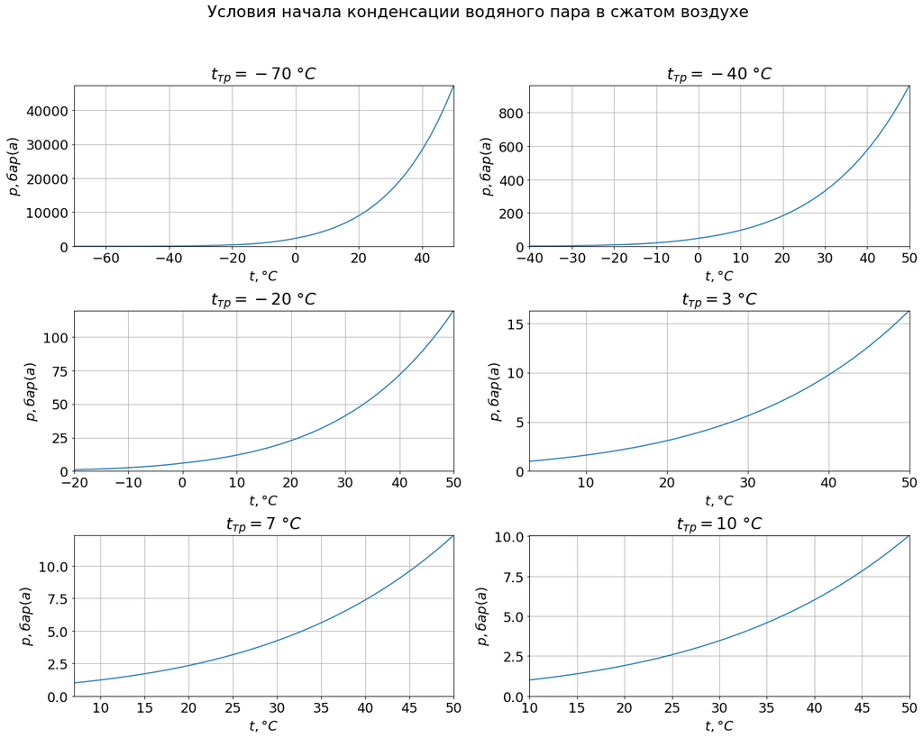

```python
import matplotlib.pyplot as plt
plt.rcParams['font.size'] = 18
fig, axes = plt.subplots(3, 2, figsize = (20, 15))
fig.suptitle("Условия начала конденсации водяного пара в сжатом воздухе")
fig.subplots_adjust(wspace=0.2, hspace=0.4)
for k in range(6):
    i = k // 2; j = k % 2
    axes[i][j].set_title('$t_{тр} =' + str(ts_dp[k]) + '\ \degree C$')
    axes[i][j].set_xlim(ts_dp[k], 50); axes[i][j].set_ylim(0, ps[k][-1])
    axes[i][j].grid()
    axes[i][j].set_xlabel('$t, \degree C$'); axes[i][j].set_ylabel('$p, бар(а)$')
    axes[i][j].plot(ts[k], ps[k])
```

## Оценка количества сконденсировавшегося водяного пара

Рассмотрим следующий случай. В ресивере под давлением 9 бар(а) находится сжатый воздух с температурой точки росы 3 С (при стандартных условиях). Определим количество конденсата в ресивере для различных значений температуры воздуха внутри ресивера при условии поддержания давления воздуха в ресивере постоянным.

1. Находим влагосодержание воздуха с заданной температурой точки росы при нормальных условиях.
2. Определяем влагосодержание в воздухе с относительной влажностью 100% при звданной температуре и давлении.
3. [1] минус [2] равно количество выпавшего конденсата.

```python
p1 = 9e5  #  давление в ресивере, Па
d1 = ds[3]  # влагосодержание в воздухе с t_тр = 3 С
d1  # г/кг
```

```
4.740959224003307
```

```python
from wetairprops import calc_t_dp_d
```

```python
# Температура точки росы. При охлаждении воздуха ниже
# температуры точки росы начинает выпадать конденсат
t1_dp = calc_t_dp_d(d1, p1)
t1_dp  # C
```

```
38.52534037651851
```

```python
t1s = np.linspace(-10, t1_dp)  #
d1s = np.array([(d1 - calc_d(t, 1., p = p1))/d1 for t in t1s])
```

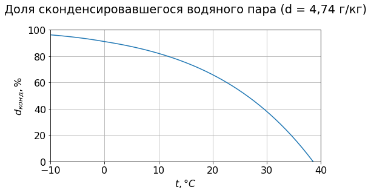

```python
fig, ax = plt.subplots(figsize = (8, 4))
plt.rcParams['font.size'] = 16
ax.set_title("Доля сконденсировавшегося водяного пара (d = 4,74 г/кг)\n");
ax.set_xlabel('$t, \degree C$');
ax.set_ylabel('$d_{конд}, \%$'); ax.plot(t1s, d1s * 100); ax.grid();
ax.set_xlim(-10, 40); ax.set_ylim(0., 100.);
```

### Ссылки

1. [Модуль для расчёта свойств влажного воздуха](https://medsv.github.io/dzen/0048/wetairprops.html)
2. [Адиабатическое охлаждение воздуха](https://medsv.github.io/dzen/0052/Адиабатическое_охлаждение.html)

[Инженерные расчёты на Python](https://zen.yandex.ru/id/5f33dcd5554adc5b33aaee83), С.В. Медведев, 2020-2022  
Использование Python и Jupyter Notebook для инженерных расчётов, С.В. Медведев, 2020-2022